# COMP4680/8650: Advanced Machine Learning

## Week 11: Deep Declarative Networks

Stephen Gould

Australian National University

Semester 2, 2022

# Overview

**Reference:** [Gould et al., "Deep Declarative Networks", TPAMI 2021](https://arxiv.org/abs/1909.04866)

- parametrized optimization problems
- declarative versus imperative nodes
- bi-level optimization
- optimality conditions and regular points
- implicit function theorem
- differentiable optimization
- examples

# Parametrized Optimization Problem

$$ \left\{ \begin{array}{lll} \text{minimize}_{u} & f(x, u) \\ \text{subject to} & h_i(x, u) = 0, & i = 1, \ldots, p \\ & g_i(x, u) \leq 0, & i = 1, \ldots, q \end{array} \right\}_{x \in \mathbb{R}^n} $$

- a family of optimization problems indexed by $x$
- assume minimum is attained by $y(x) = u^\star \in \mathbb{R}^{m}$
- $x \in \mathbb{R}^n$ are the parameters
- $f(x, u)$ is the parametrized objective, differentiable but not necessarily convex
- $h_i(x, u)$ and $g_i(x, u)$ are the parametrized equality and inequality constraint functions
- unconstrained if $p = q = 0$; equality constrained if $p \neq 0, q = 0$

**defines a solution mapping $x \mapsto y$ as**

$$ \begin{array}{rlll} y(x) \in& \text{argmin}_{u} & f(x, u) \\ & \text{subject to} & h_i(x, u) = 0, & i = 1, \ldots, p \\ & & g_i(x, u) \leq 0, & i = 1, \ldots, q. \end{array} $$

# Declarative versus Imperative Nodes

## imperative node

- implementation of the forward processing function is explicitly defined

$$ y = \tilde{f}(x; \theta) $$

- backward pass implemented by the chain rule

$$ \frac{\partial {\cal L}}{\partial x} = \tilde{f}'(x; \theta) \frac{\partial {\cal L}}{\partial y} $$

## declarative node

- exact implementation of the forward processing function is not specified
- output of forward pass results from solving an optimization problem

$$ y \in \text{argmin}_{u \in C(x, \theta)} f(x, u; \theta) $$

- backward pass is not as simple as applying the chain rule
- decouples implementation of forward and backward passes

# Bi-level Optimization

$$ \begin{array}{ll} \text{minimize}_{\theta} & {\cal L}(x, y, \theta) \\ \text{subject to} & y \in \left\{ \begin{array}{ll} \text{argmin}_{u} & f(x, u; \theta) \\ \text{subject to} & u \in C(x; \theta) \end{array} \right\} \end{array} $$

- upper-level problem is the learning problem
- lower-level problem is the inference problem
- can be solved by gradient descent if we can differentiate the solution set $y$

## Game Theoretic Perspective (Stackelberg Games)

- two player game, **leader** and **follower**
- market dictates the price for goods, $P(q_1 + q_2)$
- each player has its own cost structure, $C_i(q_i)$
- each player wants to maximize profits, $q_i P(q_1 + q_2) - C_i(q_i)$
- leader picks production quantity $q_1$ knowing that follower will respond optimally

# Regular Points

A feasible point $u$ is said to be *regular* if:

- the equality constraint gradients $\nabla_u h_i$ and the active inequality constraint gradients $\nabla_u g_i$ are linearly independent, or
- there are no equality constraints and the inequality constraints are all inactive at $u$

# Dini's Implicit Function Theorem

- Let $f: \mathbb{R}^n \times \mathbb{R}^m \to \mathbb{R}^m$ be continuously differentiable
- Let $(x, y) \in \mathbb{R}^n \times \mathbb{R}^m$ be such that $f(x, y) = 0_{m}$
- If $H = \left[ \frac{\partial f_i}{\partial y_j} \right]_{i,j=1,\ldots,m} \in \mathbb{R}^{m \times m}$ is invertible
- Then there exists an open set ${\cal X} \subseteq \mathbb{R}^n$ containing $x$ and unique continuously differentiable $g: {\cal X} \to \mathbb{R}^m$ such that
  - $g(x) = y$
  - $f(x, g(x)) = 0$ for all $x \in {\cal X}$
  - $\frac{\partial g}{\partial x_k} = -H^{-1} \left[ \frac{\partial f_i}{\partial x_k} \right]_{i=1,\ldots,m}$

## Example (sum of uniform vector)

$$ f(x, y) = \begin{bmatrix} y_1 + y_2 - x \\ y_1 - y_2 \end{bmatrix} $$

By differentiating each row $$ \frac{\text{d} y_1}{\text{d} x} + \frac{\text{d} y_2}{\text{d} x} = 1 \\ \frac{\text{d} y_1}{\text{d} x} - \frac{\text{d} y_2}{\text{d} x} = 0 $$

From Dini's IFT $$ H = \begin{bmatrix} \frac{\partial f_1}{\partial y_1} & \frac{\partial f_1}{\partial y_2} \\ \frac{\partial f_2}{\partial y_1} & \frac{\partial f_1}{\partial y_2} \\ \end{bmatrix} = \begin{bmatrix} 1 & 1 \\ 1 & -1 \end{bmatrix} $$

Therefore $$ \begin{align*} \begin{bmatrix} \frac{\text{d} y_1}{\text{d} x} \\ \frac{\text{d} y_2}{\text{d} x} \end{bmatrix} &= -H^{-1} \begin{bmatrix} \frac{\partial f_1}{\partial x} \\ \frac{\partial f_2}{\partial x} \end{bmatrix} &= -\begin{bmatrix} 0.5 & 0.5 \\ 0.5 & -0.5 \end{bmatrix}\begin{bmatrix} -1 \\ 0 \end{bmatrix} &= \begin{bmatrix} 0.5 \\ 0.5 \end{bmatrix} \end{align*} $$

# Differentiable Optimization

$$ \begin{array}{rlll} y(x) \in& \text{argmin}_{u} & f(x, u) \\ & \text{subject to} & h_i(x, u) = 0, & i = 1, \ldots, p \\ & & g_i(x, u) \leq 0, & i = 1, \ldots, q. \end{array} $$

- assume objective and constraint functions are twice differentiable
- assume solution(s) are regular points

instead of differentiating *through* argmin we differentiate the optimality conditions (with respect to $x$)

$$ \nabla_{\!y} f(x, y) + \sum_{i=1}^{q} \lambda_i \nabla_{\!y} g_i(x, y) + \sum_{i=1}^{p} \nu_i \nabla_{\!y} h_i(x, y) = 0 $$

## Unconstrained Optimization

$$ y(x) \in \text{argmin}_u f(x, u) $$

- $f: \mathbb{R}^m \times \mathbb{R}^m \to \mathbb{R}$ twice differentiable
- let

\begin{align*} H = \begin{bmatrix} \frac{\partial^2 f(x, y(x))}{\partial y_i y_j} \end{bmatrix}_{i,j=1,\ldots,m} \quad \text{and} \quad B = \begin{bmatrix} \frac{\partial^2 f(x, y(x))}{\partial y_i \partial x_j} \end{bmatrix}_{i=1,\ldots,m; j=1,\ldots,n} \end{align*}

then

\begin{align*} \text{D}y(x) = -H^{-1}B \end{align*}

where $\text{D}$ is the differential operator (matrix of partial derivatives).

## proof

- for (any) optimal $y$ we have the first-order optimality condition

$$ \text{D}_Y f(x, y) = 0 $$

- differentiating both sides with respect to $x$ we have

\begin{align*} \text{LHS} &= \text{D} \left( \text{D}_Y f(x, y) \right) \\ &= \text{D}_{XY}^2 f(x, y) + \text{D}_{YY}^2 f(x, y) \text{D}y(x) \\ \\ \text{RHS} &= \text{D} \left( 0 \right) \\ &= 0 \end{align*}

- rearranging gives

$$ \text{D} y(x) = -\left(\text{D}_{YY}^2 f(x, y)\right)^{-1} \text{D}_{XY}^2 f(x, y) $$

## Equality Constrained Optimization

$$ y(x) \in \left\{ \begin{array}{ll} \text{argmin}_u & f(x, u) \\ \text{subject to} & h(x, u) = 0 \end{array} \right\} $$

- $f: \mathbb{R}^m \times \mathbb{R}^m \to \mathbb{R}$ twice differentiable
- $h: \mathbb{R}^m \times \mathbb{R}^m \to \mathbb{R}^p$ twice differentiable
- let

$$ A = \text{D}_Y h(x, y) \quad B = \text{D}_{XY}^2 f(x, y) - \lambda^T \text{D}_{XY}^2 h(x, y) \quad C = \text{D}_{X} h(x, y) \quad H = \text{D}_{YY}^2 f(x, y) - \lambda^T \text{D}_{YY}^2 h(x, y) $$

where $\lambda$ satisfies $\lambda^T A = \text{D}_{Y} f(x, y)$

then

$$ \text{D} y(x) = H^{-1} A^T \left(A H^{-1} A^T\right)^{-1} \left(AH^{-1}B - C\right) - H^{-1}B $$

## proof (sketch)

- same as for unconstrained case but applied to the equality constrained optimality condition
- block elimination to remove $\text{D} \lambda(x)$

## Inequality Constrained Optimization

$$ y(x) \in \left\{ \begin{array}{ll} \text{argmin}_u & f(x, u) \\ \text{subject to} & h(x, u) = 0 \\ & g(x, u) \preceq 0 \end{array} \right\} $$

- if $g_i(x, y)$ inactive, then it can be removed
- if $g_i(x, y) = 0$ and $\lambda_i > 0$, then it can be treated as an eqaulity constraint
- if $g_i(x, y) = 0$ and $\lambda_i = 0$, then derivative is undefined

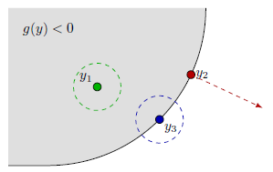

# Examples

[1. Declarative Node Worked Examples](https://nbviewer.jupyter.org/github/anucvml/ddn/blob/master/tutorials/01_simple_worked_example.ipynb)

[2. Bi-level Worked Example](https://nbviewer.jupyter.org/github/anucvml/ddn/blob/master/tutorials/02_bilevel_worked_example.ipynb)

[3. Non-regular Points](https://nbviewer.jupyter.org/github/anucvml/ddn/blob/master/tutorials/07_non_regular_points.ipynb)

[4. Optimal Transport](https://nbviewer.org/github/anucvml/ddn/blob/master/tutorials/11_optimal_transport.ipynb)